# The Pandas Library

https://dhafermalouche.net

# Contents

## Description from the Pandas documentation:

- `Pandas` is a data analysis library providing fast, flexible, and expressive data structures designed to work with relational or table-like data (SQL table or Excel spreadsheet). It is a fundamental high-level building block for doing practical, real world data analysis in Python.
- `Pandas` is well suited for:
  - Tabular data with heterogeneously-typed columns, as in an SQL table or Excel spreadsheetOrdered and unordered (not necessarily fixed-frequency) time series data.
  - Arbitrary matrix data (homogeneously typed or heterogeneous) with row and column labels
  - Any other form of observational / statistical data sets.
- The data used with `Pandas` actually doesn't need be labeled at all to be placed into a `Pandas` data structure.
- The two primary data structures of `Pandas`, Series (1-dimensional) and DataFrame (2-dimensional), handle the vast majority of typical use cases in finance, statistics, social science, and many areas of engineering.
- `Pandas` is built **on top of** `NumPy` and is intended to integrate well within a scientific computing environment with many other 3rd party libraries.

Here are just a few of the things that `Pandas` does well:

- Easy handling of missing data (represented as NaN) in floating point as well as non-floating point data
- Size mutability: columns can be inserted and deleted from DataFrame and higher dimensional objects
- Automatic and explicit data alignment: objects can be explicitly aligned to a set of labels, or the user can simply ignore the labels and let Series, DataFrame, etc. automatically align the data for you in computations
- Powerful, flexible group by functionality to perform split-apply-combine operations on data sets, for both aggregating and transforming data
- Make it easy to convert ragged, differently-indexed data in other Python and NumPy data structures into DataFrame objects
- Intelligent label-based slicing, fancy indexing, and subsetting of large data sets
- Intuitive merging and joining data sets
- Flexible reshaping and pivoting of data sets
- Hierarchical labeling of axes (possible to have multiple labels per tick)
- Robust IO tools for loading data from flat files (CSV and delimited), Excel files, databases, and saving / loading data from the ultrafast [HDF5 format](https://en.wikipedia.org/wiki/Hierarchical_Data_Format)
- Time series-specific functionality: date range generation and frequency conversion, moving window statistics, moving window linear regressions, date shifting and lagging, etc.

## Series and DataFrames

We should first import `Pandas` into `Python` after installing it from the CMD promt:

pip install pandas

```python
import pandas as pd
```

### The Panda Series

The Series data structure in `Pandas` is a one-dimensional labeled array.

- Data in the array can be of any type (integers, strings, floating point numbers, Python objects, etc.).
- Data within the array is **homogeneous**
- `Pandas` Series objects always have an index: this gives them both ndarray-like and dict-like properties.

Creating a `Panda` Serie:

- Creation from a list
- Creation from a dictionary
- Creation from a ndarray
- From an external source like a file (.csv,.xls...)

**From a list**

```python
temperature = [34, 56, 15, -9, -121, -5, 39]
days = ['Mon','Tue','Wed','Thu','Fri','Sat','Sun']

# create series
series_from_list = pd.Series(temperature, index=days)
series_from_list
```

```
Mon     34
Tue     56
Wed     15
Thu     -9
Fri   -121
Sat     -5
Sun     39
dtype: int64
```

The series should contains homogeneous types

```python
temperature = [34, 56, 'a', -9, -121, -5, 39]
days = ['Mon','Tue','Wed','Thu','Fri','Sat','Sun']
```

We create series

```python
series_from_list = pd.Series(temperature, index=days)
series_from_list
```

```
Mon      34
Tue      56
Wed       a
Thu      -9
Fri    -121
Sat      -5
Sun      39
dtype: object
```

**from a dictionary**

```python
my_dict = {'Mon': 33, 'Tue': 19, 'Wed': 15, 'Thu': 89, 'Fri': 11, 'Sat': -5, 'Sun': 9}
my_dict
```

```
{'Mon': 33, 'Tue': 19, 'Wed': 15, 'Thu': 89, 'Fri': 11, 'Sat': -5, 'Sun': 9}
```

```python
series_from_dict = pd.Series(my_dict)
series_from_dict
```

```
Mon    33
Tue    19
Wed    15
Thu    89
Fri    11
Sat    -5
Sun     9
dtype: int64
```

**From a numpy array**

```python
import numpy as np
```

I'm using `linspace` to create an array with spaced numbers over a specified interval: 15 numbers between 0 and 10

```python
my_array = np.linspace(0,10,15)
my_array
```

```
array([ 0.        ,  0.71428571,  1.42857143,  2.14285714,  2.85714286,
        3.57142857,  4.28571429,  5.        ,  5.71428571,  6.42857143,
        7.14285714,  7.85714286,  8.57142857,  9.28571429, 10.        ])
```

```python
len(my_array)
```

```
15
```

The `array` **must** be with dimension 1

```python
series_from_ndarray = pd.Series(my_array)
series_from_ndarray
```

```
0      0.000000
1      0.714286
2      1.428571
3      2.142857
4      2.857143
5      3.571429
6      4.285714
7      5.000000
8      5.714286
9      6.428571
10     7.142857
11     7.857143
12     8.571429
13     9.285714
14    10.000000
dtype: float64
```

### Pandas DataFrames

DataFrame is a 2-dimensional labeled data structure with **columns** of potentially different types. You can think of it like a spreadsheet or SQL table, or a dict of Series objects. You can create a DataFrame from:

- Dict of 1D ndarrays, lists, dicts, or Series
- 2-D numpy.ndarray
- From text, CSV, Excel files or databases
- Many other ways

**Reading the data.**

Sample data: HR Employee Attrition and Performance You can get it from here and add it to your working directory:

https://www.ibm.com/communities/analytics/watson-analytics-blog/hr-employee-attrition/

Importing the xlsx file by considering the variable EmployeeNumber as an Index variable

```python
# If Kaggle use this after uploading the xlsx into Kaggle
## data = pd.read_excel(io="../input/WA_Fn-UseC_-HR-Employee-Attrition.xlsx", sheetname=0, index_col='EmployeeNumber')
```

pd.read_excel(io="path to your excel data file, index_col='name of the column containing the row numbers or indexes')

```python
data = pd.read_excel(io="data1.xlsx",  index_col='EmployeeNumber')
```

Types of the variables

```python
data.dtypes
```

```
Age                          int64
Attrition                   object
BusinessTravel              object
DailyRate                    int64
Department                  object
DistanceFromHome             int64
Education                    int64
EducationField              object
EmployeeCount                int64
EnvironmentSatisfaction      int64
Gender                      object
HourlyRate                   int64
JobInvolvement               int64
JobLevel                     int64
JobRole                     object
JobSatisfaction              int64
MaritalStatus               object
MonthlyIncome                int64
MonthlyRate                  int64
NumCompaniesWorked           int64
Over18                      object
OverTime                    object
PercentSalaryHike            int64
PerformanceRating            int64
RelationshipSatisfaction     int64
StandardHours                int64
StockOptionLevel             int64
TotalWorkingYears            int64
TrainingTimesLastYear        int64
WorkLifeBalance              int64
YearsAtCompany               int64
YearsInCurrentRole           int64
YearsSinceLastPromotion      int64
YearsWithCurrManager         int64
dtype: object
```

A preview of the data (the first 3 rows)

```python
data.head(3)
```

| EmployeeNumber | Age | Attrition | BusinessTravel | DailyRate | Department | DistanceFromHome | Education | EducationField | EmployeeCount | EnvironmentSatisfaction | ... | RelationshipSatisfaction | StandardHours | StockOptionLevel | TotalWorkingYears | TrainingTimesLastYear | WorkLifeBalance | YearsAtCompany | YearsInCurrentRole | YearsSinceLastPromotion | YearsWithCurrManager |
| --- | --- | --- | --- | --- | --- | --- | --- | --- | --- | --- | --- | --- | --- | --- | --- | --- | --- | --- | --- | --- | --- |
| 1 | 41 | Yes | Travel_Rarely | 1102 | Sales | 1 | 2 | Life Sciences | 1 | 2 | ... | 1 | 80 | 0 | 8 | 0 | 1 | 6 | 4 | 0 | 5 |
| 2 | 49 | No | Travel_Frequently | 279 | Research & Development | 8 | 1 | Life Sciences | 1 | 3 | ... | 4 | 80 | 1 | 10 | 3 | 3 | 10 | 7 | 1 | 7 |
| 4 | 37 | Yes | Travel_Rarely | 1373 | Research & Development | 2 | 2 | Other | 1 | 4 | ... | 2 | 80 | 0 | 7 | 3 | 3 | 0 | 0 | 0 | 0 |

3 rows × 34 columns

Name of the columns in the imported data.

```python
data.columns
```

```
Index(['Age', 'Attrition', 'BusinessTravel', 'DailyRate', 'Department',
       'DistanceFromHome', 'Education', 'EducationField', 'EmployeeCount',
       'EnvironmentSatisfaction', 'Gender', 'HourlyRate', 'JobInvolvement',
       'JobLevel', 'JobRole', 'JobSatisfaction', 'MaritalStatus',
       'MonthlyIncome', 'MonthlyRate', 'NumCompaniesWorked', 'Over18',
       'OverTime', 'PercentSalaryHike', 'PerformanceRating',
       'RelationshipSatisfaction', 'StandardHours', 'StockOptionLevel',
       'TotalWorkingYears', 'TrainingTimesLastYear', 'WorkLifeBalance',
       'YearsAtCompany', 'YearsInCurrentRole', 'YearsSinceLastPromotion',
       'YearsWithCurrManager'],
      dtype='object')
```

The preview of the variable `Attrition`

```python
data['Attrition'].head()
```

```
EmployeeNumber
1    Yes
2     No
4    Yes
5     No
7     No
Name: Attrition, dtype: object
```

## Data Manipulation

Selecting some variables from the original data and displaying a preview.

```python
data[['Age', 'Gender','YearsAtCompany']].head()
```

| EmployeeNumber | Age | Gender | YearsAtCompany |
| --- | --- | --- | --- |
| 1 | 41 | Female | 6 |
| 2 | 49 | Male | 10 |
| 4 | 37 | Male | 0 |
| 5 | 33 | Female | 8 |
| 7 | 27 | Male | 2 |

Creating a new variables. Transforming the Age in years to the Age in months.

```python
data['AgeInMonths'] = 12*data['Age']
data['AgeInMonths'].head()
```

```
EmployeeNumber
1    492
2    588
4    444
5    396
7    324
Name: AgeInMonths, dtype: int64
```

Deleting the new created variable

```python
del data['AgeInMonths']
```

```python
data.columns
```

```
Index(['Age', 'Attrition', 'BusinessTravel', 'DailyRate', 'Department',
       'DistanceFromHome', 'Education', 'EducationField', 'EmployeeCount',
       'EnvironmentSatisfaction', 'Gender', 'HourlyRate', 'JobInvolvement',
       'JobLevel', 'JobRole', 'JobSatisfaction', 'MaritalStatus',
       'MonthlyIncome', 'MonthlyRate', 'NumCompaniesWorked', 'Over18',
       'OverTime', 'PercentSalaryHike', 'PerformanceRating',
       'RelationshipSatisfaction', 'StandardHours', 'StockOptionLevel',
       'TotalWorkingYears', 'TrainingTimesLastYear', 'WorkLifeBalance',
       'YearsAtCompany', 'YearsInCurrentRole', 'YearsSinceLastPromotion',
       'YearsWithCurrManager'],
      dtype='object')
```

Extracting the some observations from on specific variable

```python
data['BusinessTravel'][10:15]
```

```
EmployeeNumber
14    Travel_Rarely
15    Travel_Rarely
16    Travel_Rarely
18    Travel_Rarely
19    Travel_Rarely
Name: BusinessTravel, dtype: object
```

Extracting some rows from the whole dataframe

```python
data[10:15]
```

| EmployeeNumber | Age | Attrition | BusinessTravel | DailyRate | Department | DistanceFromHome | Education | EducationField | EmployeeCount | EnvironmentSatisfaction | ... | RelationshipSatisfaction | StandardHours | StockOptionLevel | TotalWorkingYears | TrainingTimesLastYear | WorkLifeBalance | YearsAtCompany | YearsInCurrentRole | YearsSinceLastPromotion | YearsWithCurrManager |
| --- | --- | --- | --- | --- | --- | --- | --- | --- | --- | --- | --- | --- | --- | --- | --- | --- | --- | --- | --- | --- | --- |
| 14 | 35 | No | Travel_Rarely | 809 | Research & Development | 16 | 3 | Medical | 1 | 1 | ... | 3 | 80 | 1 | 6 | 5 | 3 | 5 | 4 | 0 | 3 |
| 15 | 29 | No | Travel_Rarely | 153 | Research & Development | 15 | 2 | Life Sciences | 1 | 4 | ... | 4 | 80 | 0 | 10 | 3 | 3 | 9 | 5 | 0 | 8 |
| 16 | 31 | No | Travel_Rarely | 670 | Research & Development | 26 | 1 | Life Sciences | 1 | 1 | ... | 4 | 80 | 1 | 5 | 1 | 2 | 5 | 2 | 4 | 3 |
| 18 | 34 | No | Travel_Rarely | 1346 | Research & Development | 19 | 2 | Medical | 1 | 2 | ... | 3 | 80 | 1 | 3 | 2 | 3 | 2 | 2 | 1 | 2 |
| 19 | 28 | Yes | Travel_Rarely | 103 | Research & Development | 24 | 3 | Life Sciences | 1 | 3 | ... | 2 | 80 | 0 | 6 | 4 | 3 | 4 | 2 | 0 | 3 |

5 rows × 34 columns

Selecting specific rows from the index variable `EmployeeNumbers`

```python
selected_EmployeeNumbers = [15, 94, 337, 1120]
```

```python
data['YearsAtCompany']
```

```
EmployeeNumber
1        6
2       10
4        0
5        8
7        2
        ..
2061     5
2062     7
2064     6
2065     9
2068     4
Name: YearsAtCompany, Length: 1470, dtype: int64
```

```python
data['YearsAtCompany'].loc[selected_EmployeeNumbers]
```

```
EmployeeNumber
15      9
94      5
337     2
1120    7
Name: YearsAtCompany, dtype: int64
```

```python
data.loc[selected_EmployeeNumbers]
```

| EmployeeNumber | Age | Attrition | BusinessTravel | DailyRate | Department | DistanceFromHome | Education | EducationField | EmployeeCount | EnvironmentSatisfaction | ... | RelationshipSatisfaction | StandardHours | StockOptionLevel | TotalWorkingYears | TrainingTimesLastYear | WorkLifeBalance | YearsAtCompany | YearsInCurrentRole | YearsSinceLastPromotion | YearsWithCurrManager |
| --- | --- | --- | --- | --- | --- | --- | --- | --- | --- | --- | --- | --- | --- | --- | --- | --- | --- | --- | --- | --- | --- |
| 15 | 29 | No | Travel_Rarely | 153 | Research & Development | 15 | 2 | Life Sciences | 1 | 4 | ... | 4 | 80 | 0 | 10 | 3 | 3 | 9 | 5 | 0 | 8 |
| 94 | 29 | No | Travel_Rarely | 1328 | Research & Development | 2 | 3 | Life Sciences | 1 | 3 | ... | 4 | 80 | 1 | 6 | 3 | 3 | 5 | 4 | 0 | 4 |
| 337 | 31 | No | Travel_Frequently | 1327 | Research & Development | 3 | 4 | Medical | 1 | 2 | ... | 1 | 80 | 1 | 9 | 3 | 3 | 2 | 2 | 2 | 2 |
| 1120 | 29 | No | Travel_Rarely | 1107 | Research & Development | 28 | 4 | Life Sciences | 1 | 3 | ... | 1 | 80 | 1 | 11 | 1 | 3 | 7 | 5 | 1 | 7 |

4 rows × 34 columns

What's the `YearsAtCompany` of the row with `EmployeeNumber` equal to 94?

```python
data.loc[94,'YearsAtCompany']
```

```
5
```

Frequency of the variable `Department`

```python
data['Department'].value_counts()
```

```
Research & Development    961
Sales                     446
Human Resources            63
Name: Department, dtype: int64
```

A barplot of the variable `Department`

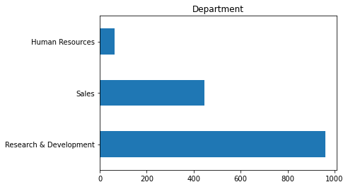

```python
data['Department'].value_counts().plot(kind='barh', title='Department')
```

Creating a pie chart

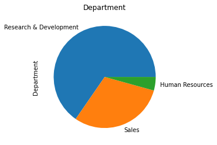

```python
data['Department'].value_counts().plot(kind='pie', title='Department')
```

Frequency of the variable `Attrition`

```python
data['Attrition'].value_counts()
```

```
No     1233
Yes     237
Name: Attrition, dtype: int64
```

Frequency in percentage

```python
data['Attrition'].value_counts(normalize=True)
```

```
No     0.838776
Yes    0.161224
Name: Attrition, dtype: float64
```

Compute the average of the variable `HourlyRate`

```python
data['HourlyRate'].mean()
```

```
65.89115646258503
```

What's the overall statisfaction of the Employees?

```python
data['JobSatisfaction'].head()
```

```
EmployeeNumber
1    4
2    2
4    3
5    3
7    2
Name: JobSatisfaction, dtype: int64
```

Let us change the levels of the variable satisfaction by creating first a disctionary

```python
JobSatisfaction_cat = {
    1: 'Low',
    2: 'Medium',
    3: 'High',
    4: 'Very High'
}
```

```python
data['JobSatisfaction'] = data['JobSatisfaction'].map(JobSatisfaction_cat)
data['JobSatisfaction'].head()
```

```
EmployeeNumber
1    Very High
2       Medium
4         High
5         High
7       Medium
Name: JobSatisfaction, dtype: object
```

```python
data['JobSatisfaction'].value_counts()
```

```
Very High    459
High         442
Low          289
Medium       280
Name: JobSatisfaction, dtype: int64
```

Computing percentages

```python
100*data['JobSatisfaction'].value_counts(normalize=True)
```

```
Very High    31.224490
High         30.068027
Low          19.659864
Medium       19.047619
Name: JobSatisfaction, dtype: float64
```

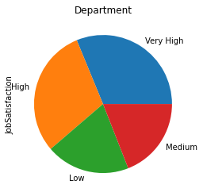

```python
data['JobSatisfaction'].value_counts(normalize=True).plot(kind='pie', title='Department')
```

```python
from pandas.api.types import CategoricalDtype
cats=['Low', 'Medium', 'High', 'Very High']
cat_type = CategoricalDtype(categories=cats, ordered=True)
data['JobSatisfaction'] = data['JobSatisfaction'].astype(cat_type)
```

```python
data['JobSatisfaction'].head()
```

```
EmployeeNumber
1    Very High
2       Medium
4         High
5         High
7       Medium
Name: JobSatisfaction, dtype: category
Categories (4, object): ['Low' < 'Medium' < 'High' < 'Very High']
```

Sorting by frequencies (it's the default option)

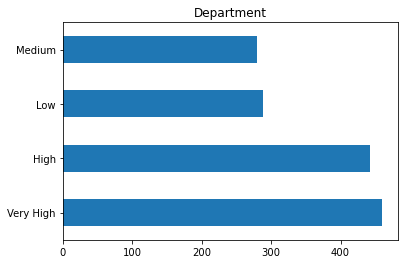

```python
data['JobSatisfaction'].value_counts().plot(kind='barh', title='Department')
```

Canceling the default sorting option and the bars will be sorted according to the categories

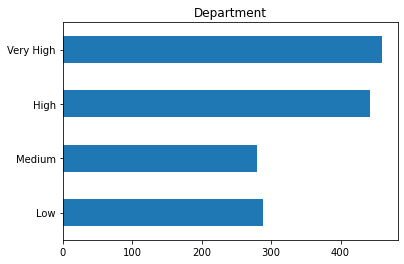

```python
data['JobSatisfaction'].value_counts(sort=False).plot(kind='barh', title='Department')
```

```python
data['JobSatisfaction'] == 'Low'
```

```
EmployeeNumber
1       False
2       False
4       False
5       False
7       False
        ...
2061    False
2062     True
2064    False
2065    False
2068    False
Name: JobSatisfaction, Length: 1470, dtype: bool
```

```python
data.loc[data['JobSatisfaction'] == 'Low'].index
```

```
Int64Index([  10,   20,   27,   31,   33,   38,   51,   52,   54,   68,
            ...
            1975, 1980, 1998, 2021, 2023, 2038, 2054, 2055, 2057, 2062],
           dtype='int64', name='EmployeeNumber', length=289)
```

```python
data['JobInvolvement'].head()
```

```
EmployeeNumber
1    3
2    2
4    2
5    3
7    3
Name: JobInvolvement, dtype: int64
```

Selecting observation of a specific interest: Those with either "Low" or "Very High" Job statisfaction

```python
subset_of_interest = data.loc[(data['JobSatisfaction'] == "Low") | (data['JobSatisfaction'] == "Very High")]
subset_of_interest.shape
```

```
(748, 34)
```

```python
subset_of_interest.head()
```

| EmployeeNumber | Age | Attrition | BusinessTravel | DailyRate | Department | DistanceFromHome | Education | EducationField | EmployeeCount | EnvironmentSatisfaction | ... | RelationshipSatisfaction | StandardHours | StockOptionLevel | TotalWorkingYears | TrainingTimesLastYear | WorkLifeBalance | YearsAtCompany | YearsInCurrentRole | YearsSinceLastPromotion | YearsWithCurrManager |
| --- | --- | --- | --- | --- | --- | --- | --- | --- | --- | --- | --- | --- | --- | --- | --- | --- | --- | --- | --- | --- | --- |
| 1 | 41 | Yes | Travel_Rarely | 1102 | Sales | 1 | 2 | Life Sciences | 1 | 2 | ... | 1 | 80 | 0 | 8 | 0 | 1 | 6 | 4 | 0 | 5 |
| 8 | 32 | No | Travel_Frequently | 1005 | Research & Development | 2 | 2 | Life Sciences | 1 | 4 | ... | 3 | 80 | 0 | 8 | 2 | 2 | 7 | 7 | 3 | 6 |
| 10 | 59 | No | Travel_Rarely | 1324 | Research & Development | 3 | 3 | Medical | 1 | 3 | ... | 1 | 80 | 3 | 12 | 3 | 2 | 1 | 0 | 0 | 0 |
| 18 | 34 | No | Travel_Rarely | 1346 | Research & Development | 19 | 2 | Medical | 1 | 2 | ... | 3 | 80 | 1 | 3 | 2 | 3 | 2 | 2 | 1 | 2 |
| 20 | 29 | No | Travel_Rarely | 1389 | Research & Development | 21 | 4 | Life Sciences | 1 | 2 | ... | 3 | 80 | 1 | 10 | 1 | 3 | 10 | 9 | 8 | 8 |

5 rows × 34 columns

```python
subset_of_interest['JobSatisfaction'].value_counts()
```

```
Very High    459
Low          289
Medium         0
High           0
Name: JobSatisfaction, dtype: int64
```

Let's then remove the categories or levels that we won't use

```python
subset_of_interest['JobSatisfaction'].cat.remove_unused_categories(inplace=True)
```

The categories 'Medium' and 'High' won't be displayed

```python
subset_of_interest['JobSatisfaction'].value_counts()
```

```
Very High    459
Low          289
Name: JobSatisfaction, dtype: int64
```

```python
grouped = subset_of_interest.groupby('JobSatisfaction')
```

```python
grouped.head()
```

| EmployeeNumber | Age | Attrition | BusinessTravel | DailyRate | Department | DistanceFromHome | Education | EducationField | EmployeeCount | EnvironmentSatisfaction | ... | RelationshipSatisfaction | StandardHours | StockOptionLevel | TotalWorkingYears | TrainingTimesLastYear | WorkLifeBalance | YearsAtCompany | YearsInCurrentRole | YearsSinceLastPromotion | YearsWithCurrManager |
| --- | --- | --- | --- | --- | --- | --- | --- | --- | --- | --- | --- | --- | --- | --- | --- | --- | --- | --- | --- | --- | --- |
| 1 | 41 | Yes | Travel_Rarely | 1102 | Sales | 1 | 2 | Life Sciences | 1 | 2 | ... | 1 | 80 | 0 | 8 | 0 | 1 | 6 | 4 | 0 | 5 |
| 8 | 32 | No | Travel_Frequently | 1005 | Research & Development | 2 | 2 | Life Sciences | 1 | 4 | ... | 3 | 80 | 0 | 8 | 2 | 2 | 7 | 7 | 3 | 6 |
| 10 | 59 | No | Travel_Rarely | 1324 | Research & Development | 3 | 3 | Medical | 1 | 3 | ... | 1 | 80 | 3 | 12 | 3 | 2 | 1 | 0 | 0 | 0 |
| 18 | 34 | No | Travel_Rarely | 1346 | Research & Development | 19 | 2 | Medical | 1 | 2 | ... | 3 | 80 | 1 | 3 | 2 | 3 | 2 | 2 | 1 | 2 |
| 20 | 29 | No | Travel_Rarely | 1389 | Research & Development | 21 | 4 | Life Sciences | 1 | 2 | ... | 3 | 80 | 1 | 10 | 1 | 3 | 10 | 9 | 8 | 8 |
| 22 | 22 | No | Non-Travel | 1123 | Research & Development | 16 | 2 | Medical | 1 | 4 | ... | 2 | 80 | 2 | 1 | 2 | 2 | 1 | 0 | 0 | 0 |
| 23 | 53 | No | Travel_Rarely | 1219 | Sales | 2 | 4 | Life Sciences | 1 | 1 | ... | 3 | 80 | 0 | 31 | 3 | 3 | 25 | 8 | 3 | 7 |
| 27 | 36 | Yes | Travel_Rarely | 1218 | Sales | 9 | 4 | Life Sciences | 1 | 3 | ... | 2 | 80 | 0 | 10 | 4 | 3 | 5 | 3 | 0 | 3 |
| 31 | 34 | Yes | Travel_Rarely | 699 | Research & Development | 6 | 1 | Medical | 1 | 2 | ... | 3 | 80 | 0 | 8 | 2 | 3 | 4 | 2 | 1 | 3 |
| 33 | 32 | Yes | Travel_Frequently | 1125 | Research & Development | 16 | 1 | Life Sciences | 1 | 2 | ... | 2 | 80 | 0 | 10 | 5 | 3 | 10 | 2 | 6 | 7 |

10 rows × 34 columns

```python
grouped.groups
```

```
{'Low': [10, 20, 27, 31, 33, 38, 51, 52, 54, 68, 70, 74, 75, 81, 86, 88, 100, 101, 113, 124, 133, 134, 145, 153, 170, 190, 197, 199, 200, 235, 239, 240, 241, 244, 250, 267, 274, 282, 288, 297, 299, 303, 328, 334, 339, 340, 347, 351, 362, 369, 374, 382, 390, 396, 412, 424, 425, 429, 451, 454, 474, 48…
```

The Low statisfaction group

```python
grouped.get_group('Low').head()
```

| EmployeeNumber | Age | Attrition | BusinessTravel | DailyRate | Department | DistanceFromHome | Education | EducationField | EmployeeCount | EnvironmentSatisfaction | ... | RelationshipSatisfaction | StandardHours | StockOptionLevel | TotalWorkingYears | TrainingTimesLastYear | WorkLifeBalance | YearsAtCompany | YearsInCurrentRole | YearsSinceLastPromotion | YearsWithCurrManager |
| --- | --- | --- | --- | --- | --- | --- | --- | --- | --- | --- | --- | --- | --- | --- | --- | --- | --- | --- | --- | --- | --- |
| 10 | 59 | No | Travel_Rarely | 1324 | Research & Development | 3 | 3 | Medical | 1 | 3 | ... | 1 | 80 | 3 | 12 | 3 | 2 | 1 | 0 | 0 | 0 |
| 20 | 29 | No | Travel_Rarely | 1389 | Research & Development | 21 | 4 | Life Sciences | 1 | 2 | ... | 3 | 80 | 1 | 10 | 1 | 3 | 10 | 9 | 8 | 8 |
| 27 | 36 | Yes | Travel_Rarely | 1218 | Sales | 9 | 4 | Life Sciences | 1 | 3 | ... | 2 | 80 | 0 | 10 | 4 | 3 | 5 | 3 | 0 | 3 |
| 31 | 34 | Yes | Travel_Rarely | 699 | Research & Development | 6 | 1 | Medical | 1 | 2 | ... | 3 | 80 | 0 | 8 | 2 | 3 | 4 | 2 | 1 | 3 |
| 33 | 32 | Yes | Travel_Frequently | 1125 | Research & Development | 16 | 1 | Life Sciences | 1 | 2 | ... | 2 | 80 | 0 | 10 | 5 | 3 | 10 | 2 | 6 | 7 |

5 rows × 34 columns

and the Very High satisfaction group

```python
grouped.get_group('Very High').head()
```

| EmployeeNumber | Age | Attrition | BusinessTravel | DailyRate | Department | DistanceFromHome | Education | EducationField | EmployeeCount | EnvironmentSatisfaction | ... | RelationshipSatisfaction | StandardHours | StockOptionLevel | TotalWorkingYears | TrainingTimesLastYear | WorkLifeBalance | YearsAtCompany | YearsInCurrentRole | YearsSinceLastPromotion | YearsWithCurrManager |
| --- | --- | --- | --- | --- | --- | --- | --- | --- | --- | --- | --- | --- | --- | --- | --- | --- | --- | --- | --- | --- | --- |
| 1 | 41 | Yes | Travel_Rarely | 1102 | Sales | 1 | 2 | Life Sciences | 1 | 2 | ... | 1 | 80 | 0 | 8 | 0 | 1 | 6 | 4 | 0 | 5 |
| 8 | 32 | No | Travel_Frequently | 1005 | Research & Development | 2 | 2 | Life Sciences | 1 | 4 | ... | 3 | 80 | 0 | 8 | 2 | 2 | 7 | 7 | 3 | 6 |
| 18 | 34 | No | Travel_Rarely | 1346 | Research & Development | 19 | 2 | Medical | 1 | 2 | ... | 3 | 80 | 1 | 3 | 2 | 3 | 2 | 2 | 1 | 2 |
| 22 | 22 | No | Non-Travel | 1123 | Research & Development | 16 | 2 | Medical | 1 | 4 | ... | 2 | 80 | 2 | 1 | 2 | 2 | 1 | 0 | 0 | 0 |
| 23 | 53 | No | Travel_Rarely | 1219 | Sales | 2 | 4 | Life Sciences | 1 | 1 | ... | 3 | 80 | 0 | 31 | 3 | 3 | 25 | 8 | 3 | 7 |

5 rows × 34 columns

**The average of the Age of each group**

```python
grouped[['Age','JobSatisfaction']].head()
```

| EmployeeNumber | Age | JobSatisfaction |
| --- | --- | --- |
| 1 | 41 | Very High |
| 8 | 32 | Very High |
| 10 | 59 | Low |
| 18 | 34 | Very High |
| 20 | 29 | Low |
| 22 | 22 | Very High |
| 23 | 53 | Very High |
| 27 | 36 | Low |
| 31 | 34 | Low |
| 33 | 32 | Low |

```python
grouped['Age'].mean()
```

```
JobSatisfaction
Low          36.916955
Very High    36.795207
Name: Age, dtype: float64
```

```python
grouped['Age'].describe()
```

| JobSatisfaction | count | mean | std | min | 25% | 50% | 75% | max |
| --- | --- | --- | --- | --- | --- | --- | --- | --- |
| Low | 289.0 | 36.916955 | 9.245496 | 19.0 | 30.0 | 36.0 | 42.0 | 60.0 |
| Very High | 459.0 | 36.795207 | 9.125609 | 18.0 | 30.0 | 35.0 | 43.0 | 60.0 |

```python
grouped['Age'].describe().unstack()
```

[output not shown]

**Comparing densities**

```
JobSatisfaction
Low          AxesSubplot(0.125,0.125;0.775x0.755)
Very High    AxesSubplot(0.125,0.125;0.775x0.755)
Name: Age, dtype: object
```

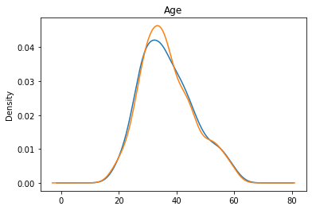

```python
grouped['Age'].plot(kind='density', title='Age')
```

**By Department**

```python
grouped['Department'].value_counts().unstack()
```

| Department JobSatisfaction | Human Resources | Research & Development | Sales |
| --- | --- | --- | --- |
| Low | 11 | 192 | 86 |
| Very High | 17 | 295 | 147 |

We can normalize it

```python
grouped['Department'].value_counts(normalize=True).unstack()
```

| Department JobSatisfaction | Human Resources | Research & Development | Sales |
| --- | --- | --- | --- |
| Low | 0.038062 | 0.664360 | 0.297578 |
| Very High | 0.037037 | 0.642702 | 0.320261 |

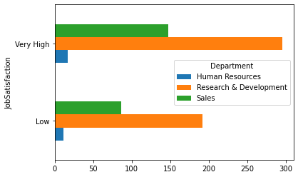

```python
grouped['Department'].value_counts().unstack().plot(kind="barh")
```

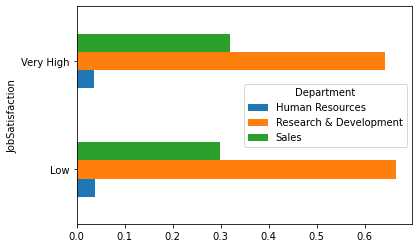

```python
grouped['Department'].value_counts(normalize=True).unstack().plot(kind="barh")
```

We can compare it with the whole sample

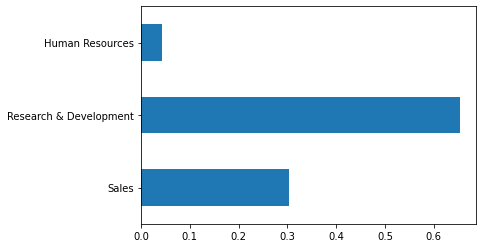

```python
data['Department'].value_counts(normalize=True,sort=False).plot(kind="barh")
```

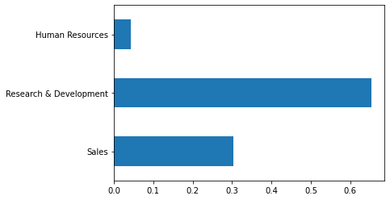

```python
data['Department'].value_counts(normalize=True,sort=False).plot(kind="barh")
```

```python
grouped['DistanceFromHome'].describe().unstack()
```

```
       JobSatisfaction
count  Low                289.000000
       Very High          459.000000
mean   Low                  9.190311
       Very High            9.030501
std    Low                  8.045127
       Very High            8.257004
min    Low                  1.000000
       Very High            1.000000
25%    Low                  2.000000
       Very High            2.000000
50%    Low                  7.000000
       Very High            7.000000
75%    Low                 14.000000
       Very High           14.000000
max    Low                 29.000000
       Very High           29.000000
dtype: float64
```

```
JobSatisfaction
Low          AxesSubplot(0.125,0.125;0.775x0.755)
Very High    AxesSubplot(0.125,0.125;0.775x0.755)
Name: DistanceFromHome, dtype: object
```

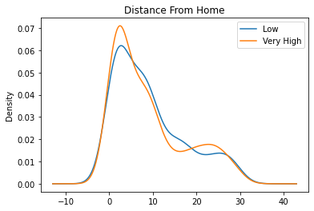

```python
grouped['DistanceFromHome'].plot(kind='density', title='Distance From Home',legend=True)
```

```python
grouped['HourlyRate'].describe()
```

| JobSatisfaction | count | mean | std | min | 25% | 50% | 75% | max |
| --- | --- | --- | --- | --- | --- | --- | --- | --- |
| Low | 289.0 | 68.636678 | 20.439515 | 30.0 | 52.0 | 72.0 | 86.0 | 100.0 |
| Very High | 459.0 | 64.681917 | 20.647571 | 30.0 | 47.0 | 64.0 | 82.5 | 100.0 |

```
JobSatisfaction
Low          AxesSubplot(0.125,0.125;0.775x0.755)
Very High    AxesSubplot(0.125,0.125;0.775x0.755)
Name: HourlyRate, dtype: object
```

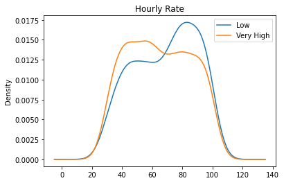

```python
grouped['HourlyRate'].plot(kind='density', title='Hourly Rate',legend=True)
```

```python
grouped['MonthlyIncome'].describe()
```

| JobSatisfaction | count | mean | std | min | 25% | 50% | 75% | max |
| --- | --- | --- | --- | --- | --- | --- | --- | --- |
| Low | 289.0 | 6561.570934 | 4645.170134 | 1091.0 | 3072.0 | 4968.0 | 8564.0 | 19943.0 |
| Very High | 459.0 | 6472.732026 | 4573.906428 | 1051.0 | 2927.5 | 5126.0 | 7908.0 | 19845.0 |

```
JobSatisfaction
Low          AxesSubplot(0.125,0.125;0.775x0.755)
Very High    AxesSubplot(0.125,0.125;0.775x0.755)
Name: HourlyRate, dtype: object
```

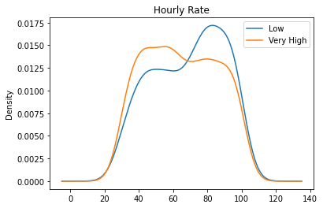

```python
grouped['HourlyRate'].plot(kind='density', title='Hourly Rate',legend=True)
```